# CATS lunges

Lunge rates of tagged whales by species, region, and prey type.

# Tag guide summary

For the four species of interest, broken out by general prey type and region, how many deployments do we have? (Filtered down to just deployments with PRHs.)

- There are 5 Antarctic humpback with unknown prey. All krill?
- There are 3 blue whales with unknown prey. All krill?

  | species | prey_general | Antarctic | N Atlantic | N Pacific | Other | S Atlantic | total |
  | --- | --- | --- | --- | --- | --- | --- | --- |
  | bb | Krill | 21 | 0 | 0 | 0 | 0 | 21 |
  | bp | Fish | 0 | 2 | 0 | 0 | 0 | 2 |
  | bp | Krill | 0 | 7 | 4 | 0 | 0 | 11 |
  | bp | Unknown | 0 | 6 | 0 | 0 | 0 | 6 |
  | bw | Krill | 0 | 1 | 56 | 3 | 0 | 60 |
  | bw | Unknown | 0 | 0 | 3 | 0 | 0 | 3 |
  | mn | Fish | 0 | 30 | 55 | 0 | 0 | 85 |
  | mn | Krill | 22 | 3 | 17 | 0 | 9 | 51 |
  | mn | Unknown | 5 | 5 | 12 | 0 | 1 | 23 |

# Lunge files

Almost all deployments have lunge files. One deployments (mn170908-44) has two. I’ll use the version with lunge confidence ratings. 14 deployments don’t have lunge files. Details on those below. I think they’re safe to ignore. One deployment is missing a PRH (remember - these are just deployments that, according to the tag guide, have PRHs). It’s a 2018 HRM mn from Monterey. Still investigating what’s going on there.

Deployments without lunges

| ID | Prey | Notes | PRH Notes |
| --- | --- | --- | --- |
| bp180829-45 | Krill | Slid low on the fin whale. Other (blue) whales visible. No verification of ID photo, but no other fin whales in the area. | NA |
| bw140820-4a | Krill | Tag slides on first lunge. A minute or so of fluking view before next lunge and tagoff. | multiple deployments. prh only for last one |
| bw140820-4b | Krill | Tag slides to perfect VGB spot, but slides during lunges. Great underside view. Compare this to bb180125-30. | multiple deployments. prh only for last one |
| bw180904-62a | Krill | Double tagged with bw180904-52 | 3 deployments on one record. Deployed with bw180904-52 |
| bw180904-62b | Krill | Tagged same whale as bw180904-44 | 3 deployments on one record. Deployed with bw180904-44 |
| bw180905-62 | Krill | Same animal as bw180905-42. Trailing animal with bw180905-49. Droned before tag on. | 3 deployments on one record. Deployed with bw180905-42 |
| mn150321-3 | Krill | Has paddlewheel for possible speed comparison. Recovery location is guess from ptrack. Some feeding on camera near sunset so very dark. Other whales in frame. | Paddles is better than flow noise here. |
| mn180608-62 | Fish | Recovery time and location are guesses from verbal description. Data had stopped working on tag, so also deployed 47 on the same animal. | NA |
| mn180621-27 | Unknown | VHF didn’t transmit. Tag was found with UHF after floating down near Nantucket. | NA |
| mn181002-48 | Fish | Short deployment. No good pics taken. Deployed near 49 deployment. | Speed was not created (not enough points to calibrate). Could be made using calibration from another deployment if needed. |
| mn190106-40 | Krill | Lots of shallow foraging, lunge feeding and bubbe netting. Tag was placed on the left side anterior to dorsal. LMG solace was in vicinity of whale for the first 3 hours after tag on. | NA |
| bb190304-18 | Krill | Tagged near LMG. No measurements, but pictures were taken from LMG. Could compare to pics of other non-tagged whales. No video/audio. Tag found in Flanders Bay. Waypoint (after data stopped) taken at … | NA |
| mn190228-42 | Krill | Paired with 44 when tagged. Views of 44’s pleats during early feeding. Observed with 3 other animals including calf later in day. Lots of logging in videos. Plays with jelly later on | NA |
| mn190309-44b | Krill | Second 44 deployment. Animal tagged and droned while logging in Andvord Bay. | NA |

Deployment without PRH

| ID | Prey | Notes | PRH Notes |
| --- | --- | --- | --- |
| mn180608-62 | Fish | Recovery time and location are guesses from verbal description. Data had stopped working on tag, so also deployed 47 on the same animal. | NA |

How many lunges per deployment?

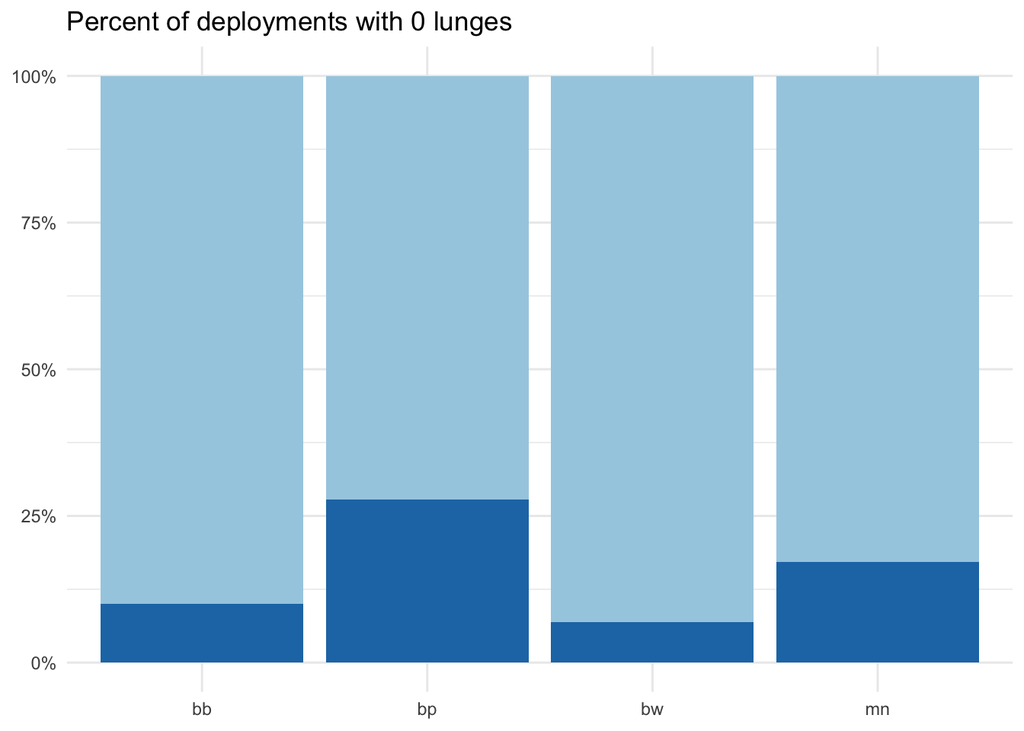

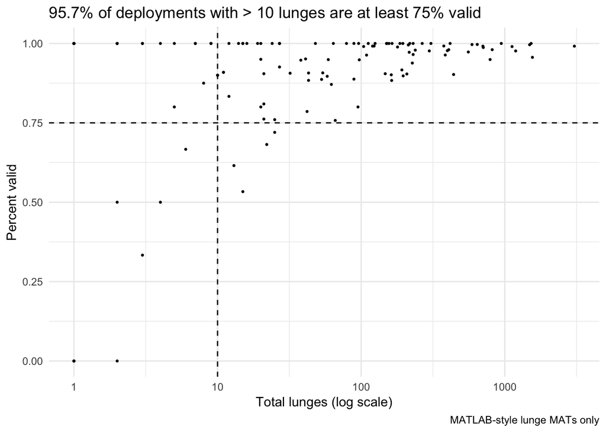

There are 15 deployments with no “feed” (according to the tag guide). Conversely, 16 deployments with “feed” but no lunges. The “no feed” with more than 1 or 2 lunges are probably worth including. **Can someone check this against Shirel’s list?**

| feed | has_lunges | n |
| --- | --- | --- |
| NA | TRUE | 1 |
| N | FALSE | 21 |
| N | TRUE | 15 |
| Y | FALSE | 16 |
| Y | TRUE | 195 |

No feeding in tag guide, but lunges recorded

| ID | species | feed | total_lunges | Notes | PRH_Notes |
| --- | --- | --- | --- | --- | --- |
| bp150619-3b | bp | N | 1 | Speed is not reliable. PRH file redone since videos were made. Lots of tag slippage. Tag begins facing forward, just anterior to the dorsal fin. Spins around to view both dorsal fin and flukes. Finall… | Speed is bad (lots of tag slips), negative slopes. Do not use the speed |
| mn140813-2 | mn | N | 1 | Epic lice video. Ends with breach but tag slides. All lats, longs and recovery times are best reconstructions. Notes from the day can not be found | Monterey Bay. Dave’s first tag. Whale Lice. |
| mn151013-7 | mn | N | 1 | Breach. Else slow travel. No feeding observed | prh redone 5.20.18. At least one breach at the beginning of video 7.Magnetometer was difficult to calibrate. Used I = [45000:49000 114000:124000] and a camoff/camon calibration |
| mn160615-37 | mn | N | 1 | Some bottom rolls but does not appear to be feeding. Swimming and surfacing with some interaction with other humpbacks. Tagged in group of 4, including 36. | Videos do not match updated prh prh redone 5.22.18. Flownoise speed unreliable, no correlation. |
| mn180105-22b | mn | N | 1 | Tag came off shortly after deployment. Good position and attachment when tagged. | NA |
| mn180626-47 | mn | N | 1 | Pretty chill whale. Potentially some searching behavior. Whale lice movement on video. | NA |
| bp180526-42 | bp | N | 2 | Paired with (and good video of) 26-44. They split and tags recovered in different locations. No apparent feeding. Bow-riding common dolphins in video 11. Deep dive of 450 m. | NA |
| mn151018-3 | mn | N | 2 | Length measurement is mean of listed values but perhaps should be verified. May be too long. Great breaching videos. Some social behavior. TDR-10 tag also deployed on the same animal. First animal ID’… | prh redone 5.21.18. Santa Barbara. TDR-10, dart attached deployment at ~3:02 pm (confirm). That tag has 32 Hz accelerometry. Several places in original csv had missing time stamp. See processing notes… |
| bb190228-18 | bb | N | 2 | Was in a pair, but videos didn’t work. Recovery right after tag off but location is just from the pseudotrack. | NA |
| mn180906-20 | mn | N | 11 | In group with 30 and 40. Most videos were corrupted from the tag. | Many of the videos were corrupted coming off of the tag. |
| mn161117-20 | mn | N | 15 | Cameras facing right pectoral flipper and possibly dorsal (mostly view of just water). A number of other humpbacks around. Sea lions in video 3, 26:15 and 29:30. PRH redone since videos were made | speedFN not a good correlation; excluded. |
| mn150622-2 | mn | N | 25 | 3 whales tagged in group. Long deployment, facing forward but see little of head, no feeding events, views of other whales passing and birds when surfacing. Camera shut off on dive and didn’t trigger,… | 1st deployment this day on a group of 3 animals (one other CATS, one acousonde). No paddlewheel attached. |
| mn180705-47 | mn | N | 41 | Poor visibility in videos, good views of blowholes, no feeeding observed. | Steady values throughout deployment |
| mn180831-11 | mn | N | 53 | Tagged in pair. Tag off time is approx. based on land listening. Picked up on the beach by a citizen. Video card was corrupted in the same way as the prior deployment of this tag. | Two periods of NaNs at 14:12:45.980 and 15:50:42.980. Last ride of the Froback (videos did not work). |
| mn151103-3 | mn | N | 112 | Likely bottom feeding. Animal often by iteslf. Some surface active behavior? Cartwheeling before tag on. | Longer of two tags, only tag with video. Froback deployed as a third tag, on whale for 27 hours, but may not have data (water damage). These whales feeding deep, echosounder data available. Not in sup… |

Feeding in tag guide, but no lunges

| ID | species | feed | total_lunges | Notes | PRH_Notes |
| --- | --- | --- | --- | --- | --- |
| bp180602-44 | bp | Y | 0 | Slow travel. At end of deployment, seems to be responding to common dolphins with lots of movement and maneuvering. Tag comes off on a series of two breaches (tag comes off on acceleration). One lunge… | Maneuvering at end coincident with common dolphin avoidance. |
| mn140716-2b | mn | Y | 0 | Flipper and flukes. Great sunset view of Moss in last video. View of whale watch boat. Potential breaching late in deployment (video off) | Monterey Bay. Some fluke strokes. prh only is for the second animal tagged with this tag. First animal is just video 2. |
| mn161005-36 | mn | Y | 0 | Snoozy whale. Do not trust speed. Partnered with Fran from yesterday and today. Bottom rolls moved tag. Interesting interactions with water. Water is very brown. Tag very loose towards end of deployme… | Bottom rolls moved tag. Speed is unreliable |
| mn170613-40 | mn | Y | 0 | Great views of nursing including views of spilled milk. Often, but not always, stays near surface while adults in group are on longer dives. Breaches tag off. | No hydrophone. Lots of surface activity near the end (cal sections 15-16) that may have confused tag frame to whale frame calculations. |
| mn170615-30 | mn | Y | 0 | Bottom feeding on sand lance. Includes great observations of other whales feeding in unusual ways. Big breach at the end. | Accel does not appear to clip during tag off breach |
| mn170815-20 | mn | Y | 0 | Friendly whale- approaches Ziphiid and John Martin. Lots of UW footage of this whale. With a partner (10). Great blow hole video. One deep dive, else surface associated. Breaches twice after biopsy. F… | Flownoise speed had trouble converging. Jiggle looks great. Great breach at end 6.6 m/s. |
| mn180620-42 | mn | Y | 0 | 41.520699999999998 | NA |
| mn180620-44 | mn | Y | 0 | Lots of bottom feeding with other whales. No additional GPS points. | NA |
| mn180620-45 | mn | Y | 0 | Cool bubble and bottom feeding, weird speed plot. Breach! | NA |
| mn180621-47 | mn | Y | 0 | Tag came off and was redeployed on the same whale. Great bottom feeding views of other whales with open mouths. | Tag fell off and was redeployed on the same animal. |
| mn180622-42 | mn | Y | 0 | Group bottom feeding | NA |
| mn180622-44 | mn | Y | 0 | More typical high speed “lunges” along the bottom. Lots of sand | NA |
| mn180624-42 | mn | Y | 0 | Lots of bottom feeding and other whales. Many birds. Had to fill in 1 min of data | NA |
| mn180624-45 | mn | Y | 0 | Great bubble net footage | NA |
| mn180624-47a | mn | Y | 0 | A very short deployment, only one dive and surface series | NA |
| mn180906-47 | mn | Y | 0 | Smaller animal in a group of three when tagged. May have been in a larger aggregation later on. | NA |

# Deployment durations

Deployments with >1 minute difference between tag guide and PRH

[output not shown]

Lunge rates generally decrease with body size. A few notes: the N Atlantic fin whales were mostly from the Azores and the tags tended to drop off at the first lunge, so they probably should be excluded. But there’s one 28 hr deployment on a fin from Greenland that looks like good quality. The blue whales from Other are all from the Chile project and should be excluded. The S Atlantic humpbacks are mostly from the super group work I think, but their lunge rates don’t seem significantly higher than the Antarctic individuals.

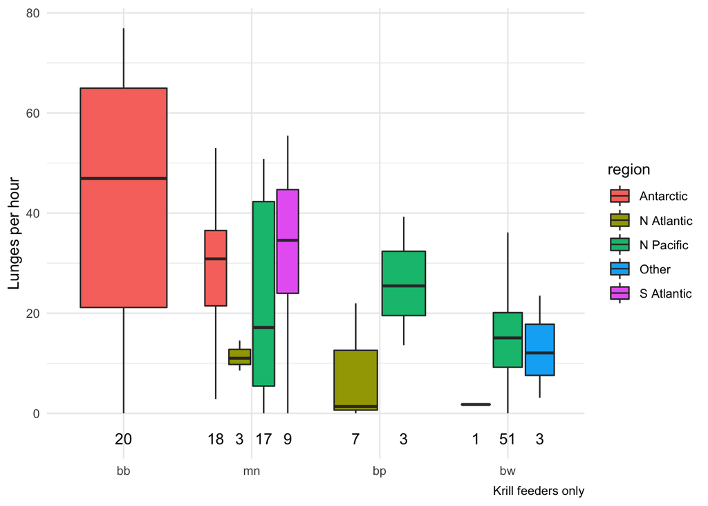

Krill-feeder sample sizes by species and region

| species | region | n |
| --- | --- | --- |
| bb | Antarctic | 20 |
| bp | N Atlantic | 7 |
| bp | N Pacific | 3 |
| bw | N Atlantic | 1 |
| bw | N Pacific | 51 |
| bw | Other | 3 |
| mn | Antarctic | 18 |
| mn | N Atlantic | 3 |
| mn | N Pacific | 17 |
| mn | S Atlantic | 9 |

# Day/night lunge rates